# Cleaning Various Datasets

Jonathan Hernandez

October 4, 2016

#### This Project is for analyzing 3 different datasets from forums on the

#### CUNY SPS IS607 Fall 2016, clean and tidy the data using dplyr and tidyr

#### and then analyzing the data.

#### First dataset to look at; a table showing income based on various religion

#### traditions.

```r
# load the income_religion dataset
income_religion <- read.csv("/home/jonboy1987/Desktop/CUNYSPS/IS607/Assignments/Project2/religion_income.csv")
names(income_religion)
```

```
## [1] "Religious.tradition" "Less.than..30.000"   "X.30.000..49.999"
## [4] "X.50.000..99.999"    "X.100.000.or.more"   "Sample.Size"
```

```r
# Change the attribute names of the dataset
colnames(income_religion) <- c("Religion", "Low_Class",
                               "Middle_Class_1", "Middle_Class_2",
                               "Upper_Middle_Class", "Sample_Size")

income_religion
```

```
##                            Religion Low_Class Middle_Class_1
## 1                          Buddhist       36%            18%
## 2                          Catholic       36%            19%
## 3            Evangelical Protestant       35%            22%
## 4                             Hindu       17%            13%
## 5     Historically Black Protestant       53%            22%
## 6                 Jehovah's Witness       48%            25%
## 7                            Jewish       16%            15%
## 8               Mainline Protestant       29%            20%
## 9                            Mormon       27%            20%
## 10                           Muslim       34%            17%
## 11               Orthodox Christian       18%            17%
## 12 Unaffiliated (religious "nones")       33%            20%
##    Middle_Class_2 Upper_Middle_Class Sample_Size
## 1             32%                13%         233
## 2             26%                19%        6137
## 3             28%                14%        7462
## 4             34%                36%         172
## 5             17%                 8%        1704
## 6             22%                 4%         208
## 7             24%                44%         708
## 8             28%                23%        5208
## 9             33%                20%         594
## 10            29%                20%         205
## 11            36%                29%         155
## 12            26%                21%        6790
```

#### Data Dictionary

- Low_class –> income < $30,000
- Middle_Class_1 –> income between $30,000 and $49,999 inclusive
- Middle_Class_2 –> income between $50,000 and $99,999 inclusive
- Upper_Middle_Class –> income $100k or more

#### Let’s use the dplyr and tidyr packages and combine the incomes into

#### one column

```r
# Tidy up the dataset by grouping the income levels into a single column
tidy_income_religion <- income_religion %>% gather(Working_Class,
                                                   percentage_income, 2:5)

# Check out the new dataset
tidy_income_religion
```

```
##                            Religion Sample_Size      Working_Class
## 1                          Buddhist         233          Low_Class
## 2                          Catholic        6137          Low_Class
## 3            Evangelical Protestant        7462          Low_Class
## 4                             Hindu         172          Low_Class
## 5     Historically Black Protestant        1704          Low_Class
## 6                 Jehovah's Witness         208          Low_Class
## 7                            Jewish         708          Low_Class
## 8               Mainline Protestant        5208          Low_Class
## 9                            Mormon         594          Low_Class
## 10                           Muslim         205          Low_Class
## 11               Orthodox Christian         155          Low_Class
## 12 Unaffiliated (religious "nones")        6790          Low_Class
## 13                         Buddhist         233     Middle_Class_1
## 14                         Catholic        6137     Middle_Class_1
```

[output cut: 83 more lines]

```r
summary(tidy_income_religion)
```

```
##                           Religion   Sample_Size     Working_Class
##  Buddhist                     : 4   Min.   : 155.0   Length:48
##  Catholic                     : 4   1st Qu.: 207.2   Class :character
##  Evangelical Protestant       : 4   Median : 651.0   Mode  :character
##  Hindu                        : 4   Mean   :2464.7
##  Historically Black Protestant: 4   3rd Qu.:5440.2
##  Jehovah's Witness            : 4   Max.   :7462.0
##  (Other)                      :24
##  percentage_income
##  Length:48
##  Class :character
##  Mode  :character
##
##
##
##
```

```r
# As people make more money, do percentage of Jehova witnesses decrease?
JehovaW <- filter(tidy_income_religion, Religion == "Jehovah's Witness")
JehovaW
```

```
##            Religion Sample_Size      Working_Class percentage_income
## 1 Jehovah's Witness         208          Low_Class               48%
## 2 Jehovah's Witness         208     Middle_Class_1               25%
## 3 Jehovah's Witness         208     Middle_Class_2               22%
## 4 Jehovah's Witness         208 Upper_Middle_Class                4%
```

#### Second dataset to examine (Social Networking Use)

#### http://www.pewresearch.org/data-trend/media-and-technology/social-networking-use/

```r
social_net_use <- read.csv('/home/jonboy1987/Desktop/CUNYSPS/IS607/Assignments/Project2/socialNetworkingUse.csv')
social_net_use
```

```
##       Date All.internet.users X18.29 X30.49 X50.64 X65.
## 1   2/2005                  8      9      7      6    —
## 2   8/2006                 16     49      8      4    1
## 3   5/2008                 29     67     25     11    7
## 4   4/2009                 46     76     48     24   13
## 5   5/2010                 61     86     61     47   26
## 6   8/2011                 64     87     68     49   29
## 7   2/2012                 66     86     72     50   34
## 8   8/2012                 69     92     73     57   38
## 9  12/2012                 67     83     77     52   32
## 10  5/2013                 72     89     78     60   43
## 11  1/2014                 74     89     89     65   49
## 12  7/2015                 76     92     81     67   56
```

```r
# Change the attribute names around
colnames(social_net_use) <- c("Date", "All_Internet_Users", "Young_Adults",
                              "Adults_Middleage1", "Adults_Middleage2",
                              "Seniors")
names(social_net_use)
```

```
## [1] "Date"               "All_Internet_Users" "Young_Adults"
## [4] "Adults_Middleage1"  "Adults_Middleage2"  "Seniors"
```

```r
# combine the age groups into one variable namely Age for a more tidy dataset

tidy_social_net_use <- social_net_use %>% gather(Age_Group, num_users, 2:6)
tidy_social_net_use
```

```
##       Date          Age_Group num_users
## 1   2/2005 All_Internet_Users         8
## 2   8/2006 All_Internet_Users        16
## 3   5/2008 All_Internet_Users        29
## 4   4/2009 All_Internet_Users        46
## 5   5/2010 All_Internet_Users        61
## 6   8/2011 All_Internet_Users        64
## 7   2/2012 All_Internet_Users        66
## 8   8/2012 All_Internet_Users        69
## 9  12/2012 All_Internet_Users        67
## 10  5/2013 All_Internet_Users        72
## 11  1/2014 All_Internet_Users        74
## 12  7/2015 All_Internet_Users        76
## 13  2/2005       Young_Adults         9
## 14  8/2006       Young_Adults        49
```

[output cut: 46 more lines]

#### Data Dictionary for the age groups in the tidy dataset:

- Young_Adults –> people who were 18-29 years of age
- Adults_Middleage1 –> people who were 30-49 years of age
- Adults_Middleage2 –> people who were 50-64 years of age
- Seniors –> people who were 65+ years of age

#### Do some Analysis on the second dataset; A dataset that shows Social Network

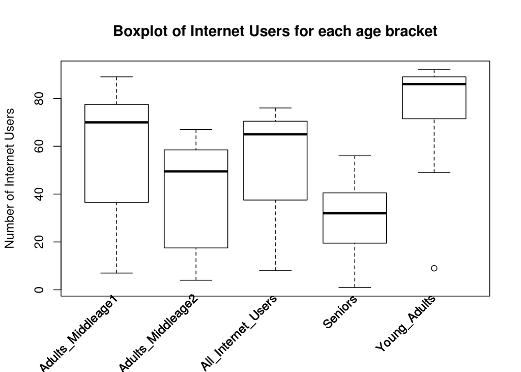

```r
# Show the boxplots of each type of age group

# convert Age_group to factors and not characters
tidy_social_net_use <- tidy_social_net_use %>%
  mutate_each(funs(factor), Age_Group) %>%
  mutate_each(funs(as.numeric), num_users)

# Plot the boxplot
with(tidy_social_net_use,
                 plot(Age_Group, num_users,
                      main = "Boxplot of Internet Users for each age bracket",
                      ylab = "Number of Internet Users", xaxt = "n"))
labels <- tidy_social_net_use$Age_Group
text(labels, labels = labels,
     par("usr")[3] - .25, srt = 45, xpd = TRUE, adj = 1, cex.axis = .75)
```

#### Now to examine the final dataset; a dataset that shows crimes in

#### Chicago, IL since 2001

### Note: this is a ~ 1.4 GB dataset so make sure you have enough RAM to load

### into R.

#### data can be found at https://data.cityofchicago.org/view/5cd6-ry5g

#### Examine the dataset in more detail and get a sense of the data

```r
str(chicago_crimes)
```

```
## Classes 'data.table' and 'data.frame':   6176743 obs. of  22 variables:
##  $ ID                  : int  10001595 10007031 10009684 10012713 10033820 10158010 10292456 10296227 10296236 10296237 ...
##  $ Case Number         : chr  "HY191041" "HY196398" "HY199045" "HY202475" ...
##  $ Date                : chr  "11/02/2014 05:57:00 AM" "03/08/2015 09:00:00 AM" "03/08/2015 04:00:00 AM" "03/08/2015 08:00:00 AM" ...
##  $ Block               : chr  "003XX W 110TH ST" "082XX S EVANS AVE" "018XX N SHEFFIELD AVE" "084XX S EXCHANGE AVE" ...
##  $ IUCR                : chr  "2825" "1155" "1150" "5002" ...
##  $ Primary Type        : chr  "OTHER OFFENSE" "DECEPTIVE PRACTICE" "DECEPTIVE PRACTICE" "OTHER OFFENSE" ...
##  $ Description         : chr  "HARASSMENT BY TELEPHONE" "AGGRAVATED FINANCIAL IDENTITY THEFT" "CREDIT CARD FRAUD" "OTHER VEHICLE OFFENSE" ...
##  $ Location Description: chr  "RESIDENCE" "APARTMENT" "RESIDENCE" "STREET" ...
##  $ Arrest              : chr  "false" "false" "false" "false" ...
##  $ Domestic            : chr  "false" "false" "false" "true" ...
##  $ Beat                : int  513 631 1813 423 1412 924 1524 922 1424 224 ...
##  $ District            : int  5 6 18 4 14 9 15 9 14 2 ...
##  $ Ward                : int  34 6 43 10 35 3 37 14 1 3 ...
##  $ Community Area      : int  49 44 7 46 21 61 25 58 24 38 ...
##  $ FBI Code            : chr  "26" "11" "11" "26" ...
##  $ X Coordinate        : int  1176052 1182660 1169343 1197281 1152188 1165992 NA 1158073 1163043 1177976 ...
##  $ Y Coordinate        : int  1831981 1850549 1912524 1849663 1920160 1874208 NA 1873363 1910387 1872910 ...
##  $ Year                : int  2014 2015 2015 2015 2014 2015 2014 2015 2015 2015 ...
##  $ Updated On          : chr  "02/04/2016 06:33:39 AM" "08/17/2015 03:03:40 PM" "08/17/2015 03:03:40 PM" "08/17/2015 03:03:40 PM" ...
##  $ Latitude            : num  41.7 41.7 41.9 41.7 41.9 ...
##  $ Longitude           : num  -87.6 -87.6 -87.7 -87.6 -87.7 ...
##  $ Location            : chr  "(41.694312, -87.631046)" "(41.745115, -87.606279)" "(41.915478, -87.653277)" "(41.742332, -87.552736)" ...
##  - attr(*, ".internal.selfref")=<externalptr>
```

```r
summary(chicago_crimes)
```

```
##        ID           Case Number            Date
##  Min.   :     634   Length:6176743     Length:6176743
##  1st Qu.: 3249580   Class :character   Class :character
##  Median : 5735233   Mode  :character   Mode  :character
##  Mean   : 5775611
##  3rd Qu.: 8176338
##  Max.   :10709001
##
##     Block               IUCR           Primary Type
##  Length:6176743     Length:6176743     Length:6176743
##  Class :character   Class :character   Class :character
##  Mode  :character   Mode  :character   Mode  :character
##
##
##
##
##  Description        Location Description    Arrest
##  Length:6176743     Length:6176743       Length:6176743
##  Class :character   Class :character     Class :character
##  Mode  :character   Mode  :character     Mode  :character
##
##
##
##
##    Domestic              Beat         District          Ward
##  Length:6176743     Min.   : 111   Min.   : 1.00   Min.   : 1.0
##  Class :character   1st Qu.: 623   1st Qu.: 6.00   1st Qu.:10.0
##  Mode  :character   Median :1111   Median :10.00   Median :22.0
##                     Mean   :1196   Mean   :11.31   Mean   :22.6
##                     3rd Qu.:1732   3rd Qu.:17.00   3rd Qu.:34.0
##                     Max.   :2535   Max.   :31.00   Max.   :50.0
##                                    NA's   :49      NA's   :614865
##  Community Area     FBI Code          X Coordinate      Y Coordinate
##  Min.   : 0.0     Length:6176743     Min.   :      0   Min.   :      0
##  1st Qu.:23.0     Class :character   1st Qu.:1152908   1st Qu.:1859144
##  Median :32.0     Mode  :character   Median :1165916   Median :1890181
##  Mean   :37.7                        Mean   :1164472   Mean   :1885624
##  3rd Qu.:58.0                        3rd Qu.:1176339   3rd Qu.:1909355
##  Max.   :77.0                        Max.   :1205119   Max.   :1951622
##  NA's   :616052                      NA's   :68415     NA's   :68415
##       Year       Updated On           Latitude       Longitude
##  Min.   :2001   Length:6176743     Min.   :36.62   Min.   :-91.69
##  1st Qu.:2004   Class :character   1st Qu.:41.77   1st Qu.:-87.71
##  Median :2007   Mode  :character   Median :41.85   Median :-87.67
##  Mean   :2007                      Mean   :41.84   Mean   :-87.67
##  3rd Qu.:2011                      3rd Qu.:41.91   3rd Qu.:-87.63
##  Max.   :2016                      Max.   :42.02   Max.   :-87.52
##                                    NA's   :68415   NA's   :68415
##    Location
##  Length:6176743
##  Class :character
##  Mode  :character
##
##
##
##
```

#### Examine the crimes that had an arrest and where the primary reason and/or

#### description was either an “assault” or “theft” only

#### But lets clean some portion of this dataset first

```r
# update underscores of the attribute names with a '_' symbol so the attribute
# names can be referenced with '$'
colnames(chicago_crimes) <- gsub(" ", "_", colnames(chicago_crimes))

# make the Primary_Type, Description, "Arrest" factor variables instead of
# character vectors (better to work with)
tidy_chicago_crimes <- chicago_crimes %>%
  mutate_each_(funs(factor), c("Primary_Type", "Description", "Arrest"))

# select the data where Arrest == true and the primary type or description have
# the words assault or theft in them

tidy_chicago_crimes_arrest <- tidy_chicago_crimes %>% filter(Arrest == "true")

# Any arrests dealing with assault?
tidy_chicago_crimes_arrest_assault <-
  tidy_chicago_crimes_arrest[grepl("assault",
                                   tidy_chicago_crimes_arrest$Description,
                                   ignore.case = TRUE) |
                               grepl("assault",
                                     tidy_chicago_crimes_arrest$Primary_Type,
                                     ignore.case = TRUE), ]
# Any arrests dealing with theft?
tidy_chicago_crimes_arrest_theft <-
  tidy_chicago_crimes_arrest[grepl("theft",
                                   tidy_chicago_crimes_arrest$Description,
                                   ignore.case = TRUE) |
                               grepl("theft",
                                     tidy_chicago_crimes_arrest$Primary_Type,
                                     ignore.case = TRUE), ]

dim(tidy_chicago_crimes_arrest_theft)
```

```
## [1] 207813     22
```

```r
dim(tidy_chicago_crimes_arrest_assault)
```

```
## [1] 93427    22
```

#### since 2001.